# IMPORTING THE PFIZER DATA-SET

- The following data-set consist of tweets from the month of 'January' to the month of 'May'based on the keyword [Pfizer] which has been scrapped from twitter using the library called snscrape
- Our scrapped data consist of the Url, date of the tweet, tweet_content, tweet_id
- For our Analysis we will be only making use of the tweet content inorder to get the sentiment Analysis for the given time duration

```python
import pandas as pd
df= pd.read_csv('/content/drive/MyDrive/Colab Notebooks/PFizer_tweets_01-05.csv',low_memory=False)
df
```

|  | Unnamed: 0 | Unnamed: 0.1 | _type | url | date | content | renderedContent | id | user | replyCount | retweetCount | likeCount | quoteCount | conversationId | lang | source | sourceUrl | sourceLabel | outlinks | tcooutlinks | media | retweetedTweet | quotedTweet | inReplyToTweetId | inReplyToUser | mentionedUsers | coordinates | place | hashtags | … |
| --- | --- | --- | --- | --- | --- | --- | --- | --- | --- | --- | --- | --- | --- | --- | --- | --- | --- | --- | --- | --- | --- | --- | --- | --- | --- | --- | --- | --- | --- | --- |
| 0 | 0 | 0 | snscrape.modules.twitter.Tweet | https://twitter.com/mimifontaine/status/134515... | 2021-01-01 23:59:56+00:00 | @Pfizer_UK Brevinor has been out of stock in t... | @Pfizer_UK Brevinor has been out of stock in t... | 1345157843960418310 | {'_type': 'snscrape.modules.twitter.User', 'us... | 1 | 0 | 1 | 0 | 1345157843960418310 | en | <a href="https://mobile.twitter.com" rel="nofo... | https://mobile.twitter.com | Twitter Web App | NaN | NaN | NaN | NaN | NaN | NaN | NaN | [{'_type': 'snscrape.modules.twitter.User', 'u... | NaN | NaN | NaN | … |
| 1 | 1 | 1 | snscrape.modules.twitter.Tweet | https://twitter.com/sawasqa/status/13451578021... | 2021-01-01 23:59:46+00:00 | @ErnesBustamante @DylanLopezE96 ¿Los alemanes ... | @ErnesBustamante @DylanLopezE96 ¿Los alemanes ... | 1345157802113826816 | {'_type': 'snscrape.modules.twitter.User', 'us... | 1 | 0 | 0 | 0 | 1345091415836151809 | es | <a href="https://mobile.twitter.com" rel="nofo... | https://mobile.twitter.com | Twitter Web App | NaN | NaN | NaN | NaN | NaN | 1.345091e+18 | {'_type': 'snscrape.modules.twitter.User', 'us... | [{'_type': 'snscrape.modules.twitter.User', 'u... | NaN | NaN | NaN | … |
| 2 | 2 | 2 | snscrape.modules.twitter.Tweet | https://twitter.com/JoseRodolfoMara/status/134... | 2021-01-01 23:59:42+00:00 | hasta 12 semanas. Esos retrasos no se probaron... | hasta 12 semanas. Esos retrasos no se probaron... | 1345157784959127552 | {'_type': 'snscrape.modules.twitter.User', 'us... | 1 | 0 | 0 | 0 | 1345157782002135040 | es | <a href="https://mobile.twitter.com" rel="nofo... | https://mobile.twitter.com | Twitter Web App | NaN | NaN | NaN | NaN | NaN | 1.345158e+18 | {'_type': 'snscrape.modules.twitter.User', 'us... | NaN | NaN | NaN | NaN | … |
| 3 | 3 | 3 | snscrape.modules.twitter.Tweet | https://twitter.com/in369/status/1345157778764... | 2021-01-01 23:59:40+00:00 | @ZooCsport @garcia_cabetas @iescolar En ningún... | @ZooCsport @garcia_cabetas @iescolar En ningún... | 1345157778764136450 | {'_type': 'snscrape.modules.twitter.User', 'us... | 1 | 0 | 0 | 0 | 1345072086063181824 | es | <a href="http://twitter.com/download/android" ... | http://twitter.com/download/android | Twitter for Android | NaN | NaN | NaN | NaN | NaN | 1.345154e+18 | {'_type': 'snscrape.modules.twitter.User', 'us... | [{'_type': 'snscrape.modules.twitter.User', 'u... | NaN | NaN | NaN | … |
| 4 | 4 | 4 | snscrape.modules.twitter.Tweet | https://twitter.com/leithlocal88/status/134515... | 2021-01-01 23:59:31+00:00 | @NHS_Lothian @WghLothian Will his second jab a... | @NHS_Lothian @WghLothian Will his second jab a... | 1345157737760649217 | {'_type': 'snscrape.modules.twitter.User', 'us... | 0 | 0 | 0 | 0 | 1336303075288559616 | en | <a href="http://twitter.com/download/iphone" r... | http://twitter.com/download/iphone | Twitter for iPhone | NaN | NaN | NaN | NaN | NaN | 1.336303e+18 | {'_type': 'snscrape.modules.twitter.User', 'us... | [{'_type': 'snscrape.modules.twitter.User', 'u... | NaN | NaN | NaN | … |
| ... | ... | ... | ... | ... | ... | ... | ... | ... | ... | ... | ... | ... | ... | ... | ... | ... | ... | ... | ... | ... | ... | ... | ... | ... | ... | ... | ... | ... | ... | … |
| 73575 | 15495 | 495 | snscrape.modules.twitter.Tweet | https://twitter.com/KarlaHidalgo08/status/1399... | 2021-05-31 23:33:12+00:00 | @irechamo Hahahahahahahaha me he reído con esa... | @irechamo Hahahahahahahaha me he reído con esa... | 1399509298003185668 | {'_type': 'snscrape.modules.twitter.User', 'us... | 0 | 0 | 3 | 0 | 1399448263066099713 | pt | <a href="http://twitter.com/download/iphone" r... | http://twitter.com/download/iphone | Twitter for iPhone | NaN | NaN | NaN | NaN | NaN | 1.399448e+18 | {'_type': 'snscrape.modules.twitter.User', 'us... | [{'_type': 'snscrape.modules.twitter.User', 'u... | NaN | NaN | NaN | … |
| 73576 | 15496 | 496 | snscrape.modules.twitter.Tweet | https://twitter.com/K1ng0fAllTrades/status/139... | 2021-05-31 23:33:01+00:00 | @shadynasty1989 @OwenJones84 The pfizer and mo... | @shadynasty1989 @OwenJones84 The pfizer and mo... | 1399509250121076738 | {'_type': 'snscrape.modules.twitter.User', 'us... | 2 | 0 | 1 | 0 | 1399104575165054980 | en | <a href="http://twitter.com/download/android" ... | http://twitter.com/download/android | Twitter for Android | NaN | NaN | NaN | NaN | NaN | 1.399121e+18 | {'_type': 'snscrape.modules.twitter.User', 'us... | [{'_type': 'snscrape.modules.twitter.User', 'u... | NaN | NaN | NaN | … |
| 73577 | 15497 | 497 | snscrape.modules.twitter.Tweet | https://twitter.com/ubknon/status/139950924392... | 2021-05-31 23:33:00+00:00 | @YVESCAU @JALLOUXChristi1 @EmmanuelMacron Il a... | @YVESCAU @JALLOUXChristi1 @EmmanuelMacron Il a... | 1399509243926036487 | {'_type': 'snscrape.modules.twitter.User', 'us... | 0 | 0 | 0 | 0 | 1399421778607448072 | pt | <a href="http://twitter.com/download/iphone" r... | http://twitter.com/download/iphone | Twitter for iPhone | NaN | NaN | NaN | NaN | NaN | 1.399447e+18 | {'_type': 'snscrape.modules.twitter.User', 'us... | [{'_type': 'snscrape.modules.twitter.User', 'u... | NaN | NaN | NaN | … |
| 73578 | 15498 | 498 | snscrape.modules.twitter.Tweet | https://twitter.com/DomIsa6/status/13995092332... | 2021-05-31 23:32:57+00:00 | @DIVIZIO1 Les Israéliens ne brillaient pas par... | @DIVIZIO1 Les Israéliens ne brillaient pas par... | 1399509233264218123 | {'_type': 'snscrape.modules.twitter.User', 'us... | 0 | 0 | 0 | 0 | 1399242761346420737 | fr | <a href="https://mobile.twitter.com" rel="nofo... | https://mobile.twitter.com | Twitter Web App | NaN | NaN | NaN | NaN | NaN | 1.399243e+18 | {'_type': 'snscrape.modules.twitter.User', 'us... | [{'_type': 'snscrape.modules.twitter.User', 'u... | NaN | NaN | NaN | … |
| 73579 | 15499 | 499 | snscrape.modules.twitter.Tweet | https://twitter.com/kamusarup/status/139950922... | 2021-05-31 23:32:54+00:00 | Pfizer's COVID-19 vaccine protects against lif... | Pfizer's COVID-19 vaccine protects against lif... | 1399509221046095873 | {'_type': 'snscrape.modules.twitter.User', 'us... | 0 | 1 | 0 | 0 | 1399509221046095873 | en | <a href="http://twitter.com/download/iphone" r... | http://twitter.com/download/iphone | Twitter for iPhone | NaN | NaN | NaN | NaN | NaN | NaN | NaN | NaN | NaN | NaN | NaN | … |

73580 rows × 30 columns

# The tweet_content which we want to deal with

```python
df = df[df["lang"]== 'en']
```

```python
df['content']
```

```
0        @Pfizer_UK Brevinor has been out of stock in t...
4        @NHS_Lothian @WghLothian Will his second jab a...
5        @pengraiggoch @ProfPCDoherty Pfizer/biontech i...
6        Almost 13,000 Pfizer-BioNTech vaccines were gi...
7        @LindaBauld Prof Linda, why not leave Pfizer p...
                               ...
73572    @pmcdunnough @veryvirology Mostly Coronavac, a...
73573    Immunosuppressed people who receive the Pfizer...
73574    @BottomleyFiona @fascinatorfun @MHRAgovuk @PHE...
73576    @shadynasty1989 @OwenJones84 The pfizer and mo...
73579    Pfizer's COVID-19 vaccine protects against lif...
Name: content, Length: 39873, dtype: object
```

# DATA ANALYSIS

```python
!pip install texthero
```

[output not shown]

# We use text Hero Package so that we can get a count of the most recurrent words in the all the scrapped tweets

- From the given count we can see that word Pfizer seems to be having the highest count amoung all the tweets from our data-set
- This provides us an overview of the data which is not cleaned

```python
import numpy as np
import pandas as pd
from copy import deepcopy

import texthero as hero
hero.top_words(df['content'].pipe(hero.clean))
```

```
pfizer           42329
vaccine          15690
co               13388
https            13292
'                 9503
                 ...
pfeiffer86           1
thayer               1
dollymad1812         1
instinctively        1
missblackme          1
Name: content, Length: 68694, dtype: int64
```

## With the help of WordCloud we can visualize the most occuring words in our data-set based on the size of the word (Greater the size of the word greater is its occurance)

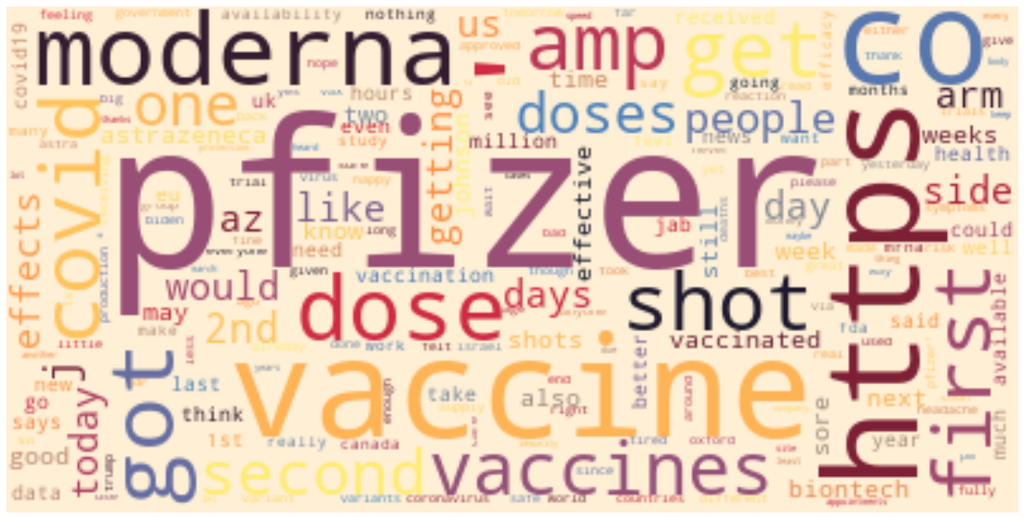

```python
hero.wordcloud(df['content'].pipe(hero.clean))
```

# DATA PREPROCESSING (CLEANING)

```python
!pip install clean-text
```

```
     |████████████████████████████████| 170 kB 4.6 MB/s
     |████████████████████████████████| 64 kB 3.0 MB/s
```

## In this step we are cleaning newline '\n' from the tweets

```python
import html
for i in range (len(df['content'])):

  x = df['content'].replace('\n','') #cleaning newline “\n” from the tweets
df['content'][i] = html.unescape(x)
df['content'].head(10)
```

```
0     @Pfizer_UK Brevinor has been out of stock in t...
4     @NHS_Lothian @WghLothian Will his second jab a...
5     @pengraiggoch @ProfPCDoherty Pfizer/biontech i...
6     Almost 13,000 Pfizer-BioNTech vaccines were gi...
7     @LindaBauld Prof Linda, why not leave Pfizer p...
9     @MartineMavi Again, I don't know who Pfizer Bi...
10    Prob is, Pfizer has said there is no data sugg...
11    @houndcl @VPrasadMDMPH Keep in mind it’s 21 da...
14    @ReigerOsmon @Kilkeerock @FionaFloyd @dannyjnw...
15    @kenlat @scrutneyfashion @Leedsjohnlufc @steph...
Name: content, dtype: object
```

# Importing NLTK libraries like stopwards and word_tokenize to perform the following Pre-Processng Tasks

- Lowercasing all your letters
- Removing hashtags, mentions, and links
- Punctuations removal (including filtering non-alphanumeric characters if necessary)
- Tokenization
- Stemming
- Lemmatization
- Stop words removal

```python
df['content']=df['content'].str.lower()
tweet=df['content'].values.tolist()
```

```python
import pandas as pd
import html
import re
from nltk.corpus import stopwords
from nltk.tokenize import word_tokenize
import nltk

def clean_tweet(tweet):
    if type(tweet) == np.float:
        return ""
    temp = tweet.lower()
    temp = re.sub("'", "", temp) # to avoid removing contractions in english
    temp = re.sub("@[A-Za-z0-9_]+","", temp)
    temp = re.sub("#[A-Za-z0-9_]+","", temp)
    temp = re.sub(r'http\S+', '', temp)
    temp = re.sub('[()!?]', ' ', temp)
    temp = re.sub('\[.*?\]',' ', temp)
    temp = re.sub("[^a-z0-9]"," ", temp)
    temp = temp.split()
    temp = [w for w in temp if not w in stopwords]
    temp = " ".join(word for word in temp)
    return temp
```

# Stemming the data

```python
import nltk
nltk.download('punkt')
from nltk.stem import PorterStemmer
from nltk.tokenize import sent_tokenize, word_tokenize
words = word_tokenize(str(tweet))
ps = PorterStemmer()
for w in tweet:
	rootWord=ps.stem(w)
	print(rootWord)
```

```
Streaming output truncated to the last 5000 lines.
@gbdeclaration @jeffereyjaxen india refuses to authorize the pfizer vaccine because of too many adverse events it says.
https://t.co/chnpzzp4wt
maybe i don't understand economics but why are we investing more money into testing for covid instead of giving the money to pfizer and moderna to manufacture the cur
president biden’s visit to pfizer in portage tomorrow demonstrates pandemic focus, sen. peters says: https://t.co/jjucd8gx5i
australia granted the oxford/az vaccine full approval. this jab along with those from pfizer/biontech &amp; moderna have only received emergency approvals in most countries.

from a secretive vaccine task force to taking millions from poor countries out of desperation, 🇨🇦 is failing. https://t.co/2x2cp3rbgf
@humble_analysis vaccines are being pushed and administered in india. the manufacturer is indian company so not depending on pfizers or modernas of the world. they actually denied pfizer’ application of eua, which was surprising but makes sense when it comes to logistics.
@indygran21 @grumpyoldgould @jamesjpdrake @pfizer indeed. it feels like a form of medical negligence and the u.k. government might have a class action against them in the future for failing to protect their citizens according to the vaccine manufacturer’s protocol. they’ve deliberately ignored it.ho…
@environomics3 @kdwuh @eantihysterja @xlilliputian @albertzvld @ad_cousin @deaconnell @rocardryan @richardjordan0 @chateau70 @skyriakideseu @astrazeneca dude,stop defending https://t.co/uvt2gear5r very simple, each pharma had chose a market were they want to be: moderna in us,az in uk ajd third worl…
@cryptonekoz got the pfizer vaccine, 1st one was fine no reaction, just a sore arm. 2nd one had a bit of reaction, tired and feverish for about 2 days then was fin
@cryptonekoz i've had my first pfizer jab for same reason as when i make it i'm going travel
@potus @thedemcoalition thanks, for your efforts! i'm an rn trained nurse,...working p/t, near pittsburgh, pa. i got the covid-19, along with my jennifer, over 6 mos. ago. i had my 2 pfizer shots! we lost dozens of patients,...from it, as well! i still have shortness of breath!!! godspeed!!! https:/…
vaccine roulette: kentucky storm continues to delay cdn vaccine delivery: health canada now says this week's delivery of 403,000 doses of pfizer-biontech's vaccine will arrive at least a day behind schedule, all doses to be delivered by friday. https://t.co/zdzkqvbluw #cdnpoli
@rtt1871 @quiscustodis prison type visiting lounges in care homes
corporate corruption illustrated via companies house, pfizer vac full of impurities..us armies of occupation are issued battlefield diapers as putin extends tarus air baseto allow nuke bombers to land  https://t.co/8bugrt8ewo
in case you are shopping for a vaccine....

comparing the covid-19 vaccines developed by pfizer, moderna, and johnson &amp; johnson https://t.co/kqto3hypev via @statnew
@egrw13 @goldsgold88 @dlane_12 @celliottability @ontariopcparty can you point us to the data that shows where trudeau "got us the vaccines"? because until this week, it was dribs &amp; drabs. this week's pfizer shipment was stuck in atlanta. partisanship is not going to win us this war.
@thepainterflynn pfizer getting my second on friday
read this article (along with the others in the sequence) and especially read the comments below the article - very interesting ....#vaccine #moderna #pfizer https://t.co/gdqporzro6
@panamena009 my dad’s cardiologist says the same, and also says the moderna vaccine has, anecdotally-this-far, been causing distressing side effects but not the pfizer one. 🧐
@erictopol @biontech_group @pfizer @moderna_tx @cdcofbc @inspq allfather gates would like to differ!

https://t.co/crnyya74cb
what we know: joe biden to visit pfizer facility in portage on thursday https://t.co/59k2gziybj
@carolinecoramuk @kheatherbrown az seems to have more sideceffects for the over 70s than the pfizer!
@nationalpost why does pfizer ship vaccine from europe bound for toronto through a small southern us city?  crazy. seems any excuse to not deliver.
since getting my first pfizer dose, they’ve messaged me weekly to report symptoms if i have any.

got one up to today. https://t.co/c0gkxst1lx
pfizer says south african covid-19 variant could significantly reduce vaccine protection https://t.co/wxq1xykqd9 https://t.co/bhkrjo5osb
pfizer says south african covid-19 variant could significantly reduce vaccine protection https://t.co/qza6mginj
@isolatedstorm @cnnbrk new studies suggest that pfizer and moderna's vaccines should protect against concerning new covid-19 variants, including one first seen in south africa
@rpcounat maybe contact @pfizer direct?
@sailorrooscout australia virtually zero cases. all in returnees. limited pfizer ➡️quarantine/health staff. govt wants us to use astra zeneca.

would u use az knowing it might not work re sa strain + prob need booster (may not work?) or wait for more pfizer/novavax?
```

[output cut: 4945 more lines]

```
@rosepetals great! i had an appointment for tomorrow to get my 1st pfizer dose but rescheduled it for friday. i'm happy too. took forever to line it up. i have heart and lung issues too and if i got the virus it might take me out. :)
full vaccine effectiveness occurs 2 weeks after the 2nd dose of the pfizer or moderna vaccines &amp; 28 days after the jnj vaccine. a list of high-risk medical conditions, along with a list of who is currently eligible to be vaccinated, can be found here: https://t.co/1eamka6zuh
@bfhd @wadepthealth while that is true, and i understand it, there are at least 2,000 65+ people confused by the process, hear there isn't vaccine this week, and are starting to seek out other places to get a 2nd dose, instead of just waiting. and since they started pfizer, they can't get j&amp;j.
@sailorrooscout i just modeled what it would take to have enough vaccines for 200m unvaccinated people by end of may.

i have j&amp;j shipping 67m by end of may, so moderna + pfizer would need to be shipping about 35m per week by the end of may, 2x mid-april numbers.

do we think that's possible?
@pepperish71 we hear the same thing in canada. i'm at a point where i am happy for whomever gets vaccinated, tho i am 70 with diabetes. if the az vaccine has to be used for younger population, then i am happy to wait my turn for a pfizer or moderna. let's just get everyone vaccinated.
@ingrahamangle bizarre claim. pfizer and moderna and j&amp;j would have done nothing?
stating #pfizer and #moderna have no liability sheild since #vaccine by definition is not legally a vaccine but instead a gene therapy originally designed as a #cancer treatment
#ati
#warpspeed
#propaganda https://t.co/wcgsygvdtk
@alisonblunt @code__green @aerialbolero @vanessabeeley @ebopface @clarkemicah @jamesdelingpole @juliahb1  this is a very interesting and detailed summary of possible vaccine side effects (pfizer) with moderna and astrazeneca to follow. long read but worth it
```

[output not shown]

```
Streaming output truncated to the last 5000 lines.
pfizer and moderna availability||7311 n. figueroa street, los angel
69/77
pfizer and moderna availability||1855 e. cochran st, simi valley
pfizer and moderna availability||369 magnolia avenue, corona
pfizer and moderna availability||500 e. manchester blvd, inglewood
pfizer only availability||1758 grand ave, grover beach
68/77
and janssen availability||2101 n. rose ave, oxnard
pfizer and moderna availability||2433 harbor blvd, ventura
pfizer and moderna availability||9000 ming avenue, bakersfield
vons 2406||750 n. imperial avenue, el centro
67/77
and janssen availability||27220 sun city blvd, sun city
moderna only availability||481 old mammoth rd, mammoth lakes
pfizer and moderna availability||535 n. mckinley street, corona
pfizer only availability||4733 e. palm canyon drive, palm spr
66/77
pfizer only availability||3610 adams avenue, san diego
pfizer only availability||4145 30th street, san diego
pfizer only availability||6155 el cajon blvd, san diego
vons 2345||1000 w. el norte parkway, escondido
65/77
pfizer and janssen (johnson and johnson) availability||2684 n. tustin st, orange
pfizer only availability||351 w. felicita ave, escondido
pfizer only availability||3900 broad street, san luis obispo
pfizer only availability||931 lomas santa fe dr, solana beach
64/77
pfizer and moderna availability||1221 gaffey street, san pedro
pfizer and moderna availability||311 w. los feliz blvd, glendale
pfizer and moderna availability||3461 w. third street, los angeles
pfizer and moderna availability||710 broadway, santa monica
63/77
and janssen availability||5500 woodruff ave, lakewood
pfizer and janssen (johnson and johnson) availability||16450 beach blvd, westminster
pfizer and moderna availability||16830 san fernando mission bvd, granada hil
62/77
and janssen availability||130 w. foothill blvd, monrovia
and janssen availability||435 foothill blvd, glendora
pfizer and moderna availability||14200 palm drive, desert hot springs
```

[output cut: 4946 more lines]

```
@citycristinah @citycynthia @fordnation @citynews i’m sure i’m just not reading it right, but i can’t seem to find anywhere where it states that you can book a second shot of pfizer, even if your first shot was moderna (i.e. are the mnra vaccines interchangeable for first and second doses)?
light at the end of the tunnel. at twickenham stadium.

very fortunate to be one of the several thousand who received the first dose of pfizer today.

#pfizer #twickenhamstadium #vaccinated https://t.co/emxjyh8moh
@terra155 @sallymcmanus @rnbreakfast “we approached the department of health back in february 2021, and offered to administer the pfizer covid-19 vaccine to our residents, staff and contractors ourselves.” tlc ceo
@sue_innovates @celliottability yes in burlington it was only pfizer , now we are stuck with moderna in stock and millions of booking requests for second dose for those who got their first dose 4 weeks ago.
 this has been the worst immunization season ever after the last flu shot season.
abc revealed-only 11% (369)of 3600 aged care workers been vaccinated -y? +y didn't morrison gov contract/designate doctors to covid vaccinate with pfizer(3 wk to 2nd)-both residents+aged care workers?thus ensuring all vaccinated?y change policy stop workers go between facilities? https://t.co/d5qgiz…
@pmcdunnough @veryvirology mostly coronavac, and pfizer for health care workers and elderly peopl
immunosuppressed people who receive the pfizer covid-19 vaccine have a 74.6% reduced risk of symptomatic infection.  https://t.co/fblmht3bve https://t.co/qyh0swzr9w
@bottomleyfiona @fascinatorfun @mhragovuk @phe_uk @astrazeneca @pfizer it should be on everything, and vaers should have it on the screenshots of individual reports.
@shadynasty1989 @owenjones84 the pfizer and moderna vaccines efficacy rate make your reply null and void. they work, plain and simpl
pfizer's covid-19 vaccine protects against life-threatening variations of the coronavirus.
```

# Lemmatizing the data

```python
import nltk
nltk.download('punkt')
nltk.download('omw-1.4')
nltk.download('wordnet')
from nltk.stem import 	WordNetLemmatizer
wordnet_lemmatizer = WordNetLemmatizer()

tokenization = nltk.word_tokenize(str(tweet))
for w in tokenization:

	print("Lemma for {} is {}".format(w, wordnet_lemmatizer.lemmatize(w)))
```

[output not shown]

[output cut: 4946 more lines]

```
Lemma for `` is ``
Lemma for pfizer is pfizer
Lemma for 's is 's
Lemma for covid-19 is covid-19
Lemma for vaccine is vaccine
Lemma for protects is protects
Lemma for against is against
Lemma for life-threatening is life-threatening
Lemma for variations is variation
Lemma for of is of
Lemma for the is the
Lemma for coronavirus is coronavirus
Lemma for . is .
Lemma for '' is ''
Lemma for ] is ]
```

```python
from nltk.corpus import stopwords
stopwords = nltk.corpus.stopwords.words('english')
results = [clean_tweet(tw) for tw in tweet]
```

# IMPORTING TEXTBLOB LIBRARY TO PERFORM SENTIMENT ANALYSIS

```python
from textblob import TextBlob

import tweepy
import sys
```

# In this step we are filtering out all the '@usernames:' and then performing sentiment Analysis based on the Polarity of the tweets

- The tweets which have polarity greater then 0 are classified to be having positive sentiments
- The tweets which have polarity less then 0 are classified t be having negitive sentiments
- The rest of the tweets are considered to be Neutral tweets

```python
polarity = 0
positive = 0
negitive = 0
neutral = 0

for tweet in results :
  final_text = tweet.replace('RT','')
  if final_text.startswith('@'):
    position = final_text.index(':')
    final_text = final_text[position+2:]
  if final_text.startswith('@'):
    position = final_text.index('')
    final_text = final_text[position+2:]
  analysis = TextBlob(final_text)
  tweet_polarity = analysis.polarity
  if tweet_polarity > 0 :
    positive += 1
  elif tweet_polarity< 0 :
    negitive += 1
  else:
    neutral += 1
  polarity += tweet_polarity
print(polarity)
print(f'Amount of positive tweets:{positive}')
print(f'Amount of negitive tweets:{negitive}')
print(f'Amount of neutral tweets:{neutral}')
```

```
3408.0196985175967
Amount of positive tweets:19181
Amount of negitive tweets:7325
Amount of neutral tweets:13367
```

```python
import matplotlib.pyplot as plt
df1 = pd.DataFrame (results, columns = ['cleaned_tweets'])
df1
```

|  | cleaned_tweets |
| --- | --- |
| 0 | brevinor stock u k almost 12 months causing de... |
| 1 | second jab appointment canceled bc political f... |
| 2 | pfizer biontech highly modified ivt rna action... |
| 3 | almost 13 000 pfizer biontech vaccines given w... |
| 4 | prof linda leave pfizer plans well using less ... |
| ... | ... |
| 39868 | mostly coronavac pfizer health care workers el... |
| 39869 | immunosuppressed people receive pfizer covid 1... |
| 39870 | everything vaers screenshots individual reports |
| 39871 | pfizer moderna vaccines efficacy rate make rep... |
| 39872 | pfizers covid 19 vaccine protects life threate... |

39873 rows × 1 columns

# Getting the Subjectivity and the Polarity of the tweets

```python
def getSubjectivity(text):
  return TextBlob(text).sentiment.subjectivity

def getPolarity(text):
  return TextBlob(text).sentiment.polarity


df1['Subjectivity']  = df1['cleaned_tweets'].apply(getSubjectivity)
df1['Polarity']  = df1['cleaned_tweets'].apply(getPolarity)
```

```python
df1
```

|  | cleaned_tweets | Subjectivity | Polarity |
| --- | --- | --- | --- |
| 0 | brevinor stock u k almost 12 months causing de... | 0.600000 | 0.700000 |
| 1 | second jab appointment canceled bc political f... | 0.200000 | 0.166667 |
| 2 | pfizer biontech highly modified ivt rna action... | 0.413333 | 0.053333 |
| 3 | almost 13 000 pfizer biontech vaccines given w... | 0.250000 | -0.250000 |
| 4 | prof linda leave pfizer plans well using less ... | 0.140476 | -0.119048 |
| ... | ... | ... | ... |
| 39868 | mostly coronavac pfizer health care workers el... | 0.500000 | 0.500000 |
| 39869 | immunosuppressed people receive pfizer covid 1... | 0.000000 | 0.000000 |
| 39870 | everything vaers screenshots individual reports | 0.400000 | 0.000000 |
| 39871 | pfizer moderna vaccines efficacy rate make rep... | 0.357143 | -0.107143 |
| 39872 | pfizers covid 19 vaccine protects life threate... | 0.000000 | 0.000000 |

39873 rows × 3 columns

# Here we can visualize a Word Cloud of the cleaned tweets

```python
from wordcloud import WordCloud
```

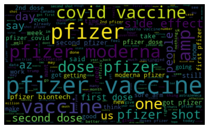

```python
allWords = ''.join([twts for twts in df1['cleaned_tweets']])
wordCloud = WordCloud(width=500,height=300,random_state=21,max_font_size=119).generate(allWords)
plt.imshow(wordCloud,interpolation = 'bilinear')
plt.axis('off')
plt.show()
```

# create a function to compute the negitive neutral and positive analysis and add it as a column in the dataframe

```python
def getAnalysis(score):
  if score < 0:
    return 'Negitive'
  elif score == 0:
    return 'Neutral'
  else:
    return 'Positive'



df1['Sentiments'] = df1['Polarity'].apply(getAnalysis)
df1
```

|  | cleaned_tweets | Subjectivity | Polarity | Sentiments |
| --- | --- | --- | --- | --- |
| 0 | brevinor stock u k almost 12 months causing de... | 0.600000 | 0.700000 | Positive |
| 1 | second jab appointment canceled bc political f... | 0.200000 | 0.166667 | Positive |
| 2 | pfizer biontech highly modified ivt rna action... | 0.413333 | 0.053333 | Positive |
| 3 | almost 13 000 pfizer biontech vaccines given w... | 0.250000 | -0.250000 | Negitive |
| 4 | prof linda leave pfizer plans well using less ... | 0.140476 | -0.119048 | Negitive |
| ... | ... | ... | ... | ... |
| 39868 | mostly coronavac pfizer health care workers el... | 0.500000 | 0.500000 | Positive |
| 39869 | immunosuppressed people receive pfizer covid 1... | 0.000000 | 0.000000 | Neutral |
| 39870 | everything vaers screenshots individual reports | 0.400000 | 0.000000 | Neutral |
| 39871 | pfizer moderna vaccines efficacy rate make rep... | 0.357143 | -0.107143 | Negitive |
| 39872 | pfizers covid 19 vaccine protects life threate... | 0.000000 | 0.000000 | Neutral |

39873 rows × 4 columns

# print all the postive tweets

```python
j =1
sortedDF =df1.sort_values(by=['Polarity'])
for i in range (0,sortedDF.shape[0]):
  if(sortedDF['Sentiments'][i]=='Positive'):
    print(str(j) + ')' + sortedDF['cleaned_tweets'][i])
    print()
    j= j+1
```

```
Streaming output truncated to the last 5000 lines.
16682)let tell pfizer good guy think

16683)glad youre safe

16684)pfizer biontech look next steps vaccine full approval younger age groups pharmacy practice news

16685)ils pfizer side effects happy get anything

16686)new dph mobile vax clinic peoples community center pfizer 05 11 total appointments location 10 age group 16 address 822 20th st los angeles ca 90011 posted 1620516383

16687)either way great soon got pfizer achy first pretty sick second make many plans days avoid

16688)v victory amp vaccine earlier got 2nd dose yonkers armory thanks amp

16689)pfizer stockholders happy expert opinions

16690)great coverage high school targeted clinic today

16691)sure beat strawman deceitful media portrays people inform try dealing reality read slightly less hidden numbers reveal read linked rebuttal nejm pfizer study

16692)point interest vaccine 50 effective approved use pfizer vaccine 70 1 dose exception elderly keep 90 away serious illness hospitals til 2nd shot based recent articles read

16693)full pfizer papi got second dose yesterday side effects today soreness arm

16694)today got first dose pfizer amp got cat great day

16695)mine yesterday lincolnshire along busy clinic full people pfizer definitely ran

16696)anyone acc wondering got pfizer feel fine rn updating

16697)pfizer vaccine actually developed biontech accepted grant 445 million german govt biontech german company pfizer accepted part operation warp speed way accepting 2 billion advance order us govt july 2020

16698)wanted super pfizer

16699)new vm pharmacy pfizer 05 10 05 14 total appointments location 95 age group 16 address 12626 south st cerritos ca 90703 posted 1620516120

16700)fact vax surge inflammatory response healthy women advised mammogram due lymph node swelling ask many vax life take work 2 days many side effects many many miss 48h work

16701)first pfizer last thursday 12 days till second shot
```

[output cut: 4945 more lines]

```
19174)proud sexy pfizer girl

19175)quebec im exact situation got az small pharmacy apt 16 weeks later end aug nobody knows anything looks like ppl got pfizer moderna able move az recipients

19176)sounds like bullshit fair paddy power wouldnt give odds 2 people age fully vaccinated pfizer family ending condition better odds winning lotto

19177)got second az today happy also ontario 300 000 doses sitting az going throw bad rather pfizer booster shot next time need

19178)many confirmed deaths one person type 1 diabetes look link lot info az nhs joined health system report issues pfizer might cause heart issues enough data yet

19179)sure reading right seem find anywhere states book second shot pfizer even first shot moderna e mnra vaccines interchangeable first second doses

19180)light end tunnel twickenham stadium fortunate one several thousand received first dose pfizer today

19181)mostly coronavac pfizer health care workers elderly people
```